# Choosing the right university

Final Independent Project for Computer Modeling Class BIOL 551

Lipi Patel

2023-05-09

## Data sets used

I am going to work with one of the Tidy Tuesday data sets, **Tuition, diversity and pay.** It consists of many data sets, however, I will be focusing on only three of them:

- *historical_tuition*
- *tuition_cost*
- *salary_potential*

## Questions to be answered using the data sets mentioned above

- **Question #1:** How has the cost of tuition in public and private institutions changed over the years?
- **Question #2:** How do the institutions in different states differ in their fees, for example, room and board, in-state tuition fees, out-of-state tuition fees, or even total fees?
- **Question #3:** What percentage of students are enrolled in STEM courses in the institutions of a particular state, for example, **California**?

### Load the libraries

```r
library(tidyverse)
library(here)
library(tidytuesdayR)
library(tidyr)
library(dbplyr)
library(ggplot2)
library(ggthemes)
library(patchwork)
library(flair)
```

### Load and read in the data

```r
historical_tuition <- readr::read_csv('https://raw.githubusercontent.com/rfordatascience/tidytuesday/master/data/2020/2020-03-10/historical_tuition.csv')
head(historical_tuition)
```

```
## # A tibble: 6 × 4
##   type             year    tuition_type    tuition_cost
##   <chr>            <chr>   <chr>                  <dbl>
## 1 All Institutions 1985-86 All Constant           10893
## 2 All Institutions 1985-86 4 Year Constant        12274
## 3 All Institutions 1985-86 2 Year Constant         7508
## 4 All Institutions 1985-86 All Current             4885
## 5 All Institutions 1985-86 4 Year Current          5504
## 6 All Institutions 1985-86 2 Year Current          3367
```

```r
tuition_cost <- readr::read_csv('https://raw.githubusercontent.com/rfordatascience/tidytuesday/master/data/2020/2020-03-10/tuition_cost.csv')
head(tuition_cost)
```

```
## # A tibble: 6 × 10
##   name       state state…¹ type  degre…² room_…³ in_st…⁴ in_st…⁵ out_o…⁶ out_o…⁷
##   <chr>      <chr> <chr>   <chr> <chr>     <dbl>   <dbl>   <dbl>   <dbl>   <dbl>
## 1 Aaniiih N… Mont… MT      Publ… 2 Year       NA    2380    2380    2380    2380
## 2 Abilene C… Texas TX      Priv… 4 Year    10350   34850   45200   34850   45200
## 3 Abraham B… Geor… GA      Publ… 2 Year     8474    4128   12602   12550   21024
## 4 Academy C… Minn… MN      For … 2 Year       NA   17661   17661   17661   17661
## 5 Academy o… Cali… CA      For … 4 Year    16648   27810   44458   27810   44458
## 6 Adams Sta… Colo… CO      Publ… 4 Year     8782    9440   18222   20456   29238
## # … with abbreviated variable names ¹state_code, ²degree_length,
## #   ³room_and_board, ⁴in_state_tuition, ⁵in_state_total, ⁶out_of_state_tuition,
## #   ⁷out_of_state_total
```

```r
salary_potential <- readr::read_csv('https://raw.githubusercontent.com/rfordatascience/tidytuesday/master/data/2020/2020-03-10/salary_potential.csv')
head(salary_potential)
```

```
## # A tibble: 6 × 7
##    rank name                             state…¹ early…² mid_c…³ make_…⁴ stem_…⁵
##   <dbl> <chr>                            <chr>     <dbl>   <dbl>   <dbl>   <dbl>
## 1     1 Auburn University                Alabama   54400  104500      51      31
## 2     2 University of Alabama in Huntsv… Alabama   57500  103900      59      45
## 3     3 The University of Alabama        Alabama   52300   97400      50      15
## 4     4 Tuskegee University              Alabama   54500   93500      61      30
## 5     5 Samford University               Alabama   48400   90500      52       3
## 6     6 Spring Hill College              Alabama   46600   89100      53      12
## # … with abbreviated variable names ¹state_name, ²early_career_pay,
## #   ³mid_career_pay, ⁴make_world_better_percent, ⁵stem_percent
```

## OUTPUT 1: Variation in tuition cost of Private and Public institutions

### Filter the data: **historical_tuition**

*This is to keep only private and public type, and summarise by taking the average of tuition cost.*

```r
filtered_tuition <- historical_tuition %>% # creates a new df and opens historical_tuition
  separate(col = year, # chooses this column, year
         into = c("year","year_2"), # separates it into two columns: year and year_2
         sep = "-", # separated by -
         remove = TRUE) %>% # removes the original column
  filter(type == c("Public", "Private")) %>% # keeps only public and private type
  select(type, year, tuition_cost) %>% # selects these variables to add in new df, filtered_tuition
  group_by(type, year) %>% # groups by type and year
  summarise_at(vars(tuition_cost), list(mean_tuition = mean)) %>% # calculates mean tuition cost and names the new column as mean_tuition
  drop_na(mean_tuition, year) # removes empty values
head(filtered_tuition) # shows the new df
```

```
## # A tibble: 6 × 3
## # Groups:   type [1]
##   type    year  mean_tuition
##   <chr>   <chr>        <dbl>
## 1 Private 1985        11992.
## 2 Private 1995        18811.
## 3 Private 2000        22190
## 4 Private 2001        23139
## 5 Private 2002        24263
## 6 Private 2003        25624
```

### Create plot #1: Variation in tuition cost of Private and Public schools from 1985-2016

**Year Vs Tuition cost (in USD)**

```r
decorate('
         ggplot(filtered_tuition, # uses this df
         mapping = aes(x = year,
         y = mean_tuition,
         color = type,
         group = type)) + # assigns x and y axes
         geom_line() + # chooses a type of geom
         geom_point() + # adding a geom layer for better visualization
         labs(x = "Year",
         y = "Tuition cost (in USD)",
         title = "Variation in tuition cost of Private and Public schools from 1985-2016") + # adding labels to axes and title
         theme(plot.title = element_text(hjust = 0), # aligns the plot title to left
         title = element_text(face= "bold")) + # converts the text to bold
         scale_y_continuous(breaks = c(5000, 10000, 15000, 20000, 25000, 30000, 35000, 40000)) + # custom values for y axis
         theme_grey()') %>% # choooses this theme
  flair_args(color = "cornflowerblue") %>% # colors the arguments
  flair_funs(color = "coral", underline = TRUE) %>% # colors and underlines the functions
  flair_input_vals(background = "turquoise") # colors the values assigned to function arguments
```

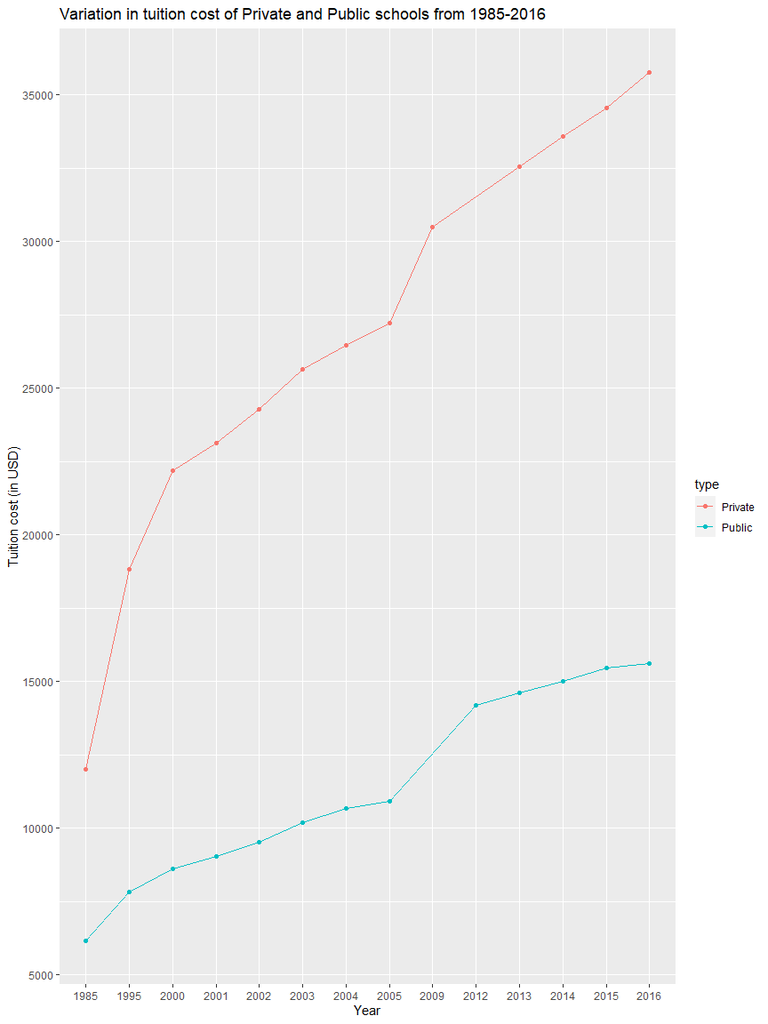

```r
ggplot(filtered_tuition, # uses this df
         mapping = aes(x = year,
         y = mean_tuition,
         color = type,
         group = type)) + # assigns x and y axes
         geom_line() + # chooses a type of geom
         geom_point() + # adding a geom layer for better visualization
         labs(x = "Year",
         y = "Tuition cost (in USD)",
         title = "Variation in tuition cost of Private and Public schools from 1985-2016") + # adding labels to axes and title
         theme(plot.title = element_text(hjust = 0), # aligns the plot title to left
         title = element_text(face= "bold")) + # converts the text to bold
         scale_y_continuous(breaks = c(5000, 10000, 15000, 20000, 25000, 30000, 35000, 40000)) + # custom values for y axis
         theme_grey()
```

### Save plot #1

```r
ggsave(here("Output","Variation in tuition.png"),
       width = 7, height = 5) # in inches)
```

## OUTPUT 2: State-wise comparison of in-state and out-of-state fees

### Filter the data: **tuition_cost**

*This is to keep private and public types only and summarise by taking mean of all the types of fees like room and board, in-state and out-of-state tuition, etc.*

```r
total_fees <- tuition_cost %>% # creates a new df, total_fees, and opens tuition_cost
  drop_na() %>% #filters out everything that is not a complete row
  dplyr::filter(type == c("Private", "Public")) %>% # specify dplyr:: if it says object'x' not found
  select(state, type, room_and_board, in_state_tuition, out_of_state_tuition, in_state_total, out_of_state_total) %>% # selects these column
  group_by(state, type) %>% # groups them
  summarise(mean_room_and_board = mean(room_and_board, na.rm = TRUE), # calculates mean of living cost
            mean_in_state_total = mean(in_state_total, na.rm = TRUE), # calculates mean of in_state total fees
            mean_out_state_total = mean(out_of_state_total, na.rm = TRUE), # calculates mean of out_of_state total fees
            mean_in_state_tuition = mean(in_state_tuition, na.rm = TRUE), # calculates mean of in_state tuition
            mean_out_state_tuition = mean(out_of_state_tuition, na.rm = TRUE)) # calculates mean of in_state tuition
head(total_fees) # shows the new df
```

```
## # A tibble: 6 × 7
## # Groups:   state [3]
##   state   type    mean_room_and_board mean_in_state_to…¹ mean_…² mean_…³ mean_…⁴
##   <chr>   <chr>                 <dbl>              <dbl>   <dbl>   <dbl>   <dbl>
## 1 Alabama Private               8915.             29301.  29301.  20386   20386
## 2 Alabama Public                7766.             17444.  27480.   9678.  19714.
## 3 Alaska  Private               7300              28130   28130   20830   20830
## 4 Alaska  Public               10700              18090   32331    7390   21631
## 5 Arizona Private               9187              38328.  38328.  29140.  29140.
## 6 Arizona Public                9251.             15540.  26657.   6289   17406.
## # … with abbreviated variable names ¹mean_in_state_total,
## #   ²mean_out_state_total, ³mean_in_state_tuition, ⁴mean_out_state_tuition
```

### Create plot #2:

**State Vs Type of fees (in USD)**

```r
### A: Create a function to enter the type of fees that you wish to compare between different states.

decorate('
         plot_fees <- function(y){ # creates a new function for "y"
         ggplot(total_fees, # chooses this df
         mapping = aes(x = state,
         y = {{y}},
         fill = type,
         group = type)) + # assigning x and y axes
         geom_col() + # choose a type of geom
         coord_flip() +
         theme_grey() + # sets this theme
         # theme(axis.text.x = element_text(angle = 45, vjust=0.8, hjust=0.8)) + # adjusting the size and position of labels on x axis
         theme(title = element_text(face= "bold")) # makes the title bold
         }


### B: Name the first plot as "p1" and second as "p2" and add axes labels to each so that it makes it easier to compare.

## For example, I have used:
#  i. mean_in_state_total
p1 <- plot_fees(mean_in_state_total) +
labs(x = "State",
     y = "In-state fees (in USD)")

# ii. mean_out_state_total
p2 <- plot_fees(mean_out_state_total) +
labs(x = "State",
     y = "Out-of-state fees (in USD)")


### C: Use "patchwork" to combine them in a single picture.
p1+p2 +
plot_layout(guides = "collect") + # groups the legends together
plot_annotation(title = "State-wise comparison of in-state and out-of-state fees") +
theme(plot.title.position = "plot") # aligns the title to center
  ') %>%
  flair_args(color = "cornflowerblue") %>% # colors all the arguments
  flair_funs(color = "coral", underline = TRUE) %>% # colors and underlines all the functions
  flair_input_vals(background = "turquoise") # colors the values assigned to function arguments
```

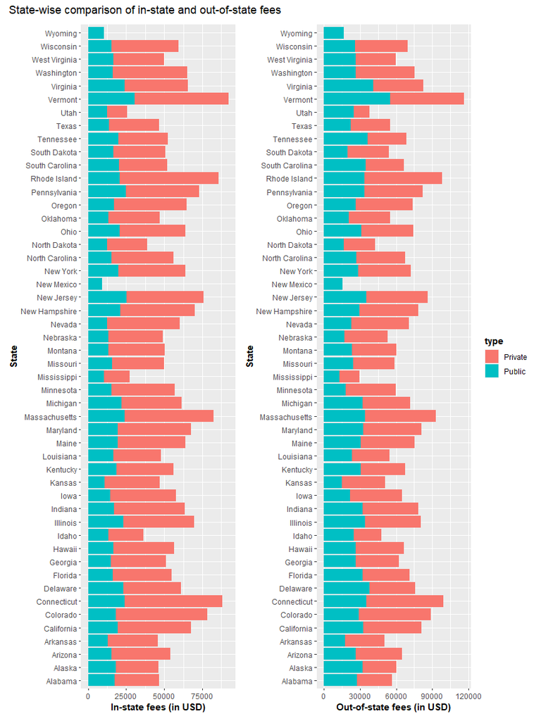

```r
plot_fees <- function(y){ # creates a new function for "y"
         ggplot(total_fees, # chooses this df
         mapping = aes(x = state,
         y = {{y}},
         fill = type,
         group = type)) + # assigning x and y axes
         geom_col() + # choose a type of geom
         coord_flip() +
         theme_grey() + # sets this theme
         # theme(axis.text.x = element_text(angle = 45, vjust=0.8, hjust=0.8)) + # adjusting the size and position of labels on x axis
         theme(title = element_text(face= "bold")) # makes the title bold
         }


### B: Name the first plot as "p1" and second as "p2" and add axes labels to each so that it makes it easier to compare.

## For example, I have used:
#  i. mean_in_state_total
p1 <- plot_fees(mean_in_state_total) +
labs(x = "State",
     y = "In-state fees (in USD)")

# ii. mean_out_state_total
p2 <- plot_fees(mean_out_state_total) +
labs(x = "State",
     y = "Out-of-state fees (in USD)")


### C: Use "patchwork" to combine them in a single picture.
p1+p2 +
plot_layout(guides = "collect") + # groups the legends together
plot_annotation(title = "State-wise comparison of in-state and out-of-state fees") +
theme(plot.title.position = "plot") # aligns the title to center
```

#### Similarly, any other variables in the df can be used to compare by just inputting the value for y and adding labels to the plot.

### Save plot #2

```r
ggsave(here("Output","Total fees in public & private institutions of the US.png"),
       width = 12, height = 9) # in inches)
```

## OUTPUT 3: Percentage of students enrolled in STEM fields in Californian institutions

### Filter data: **salary_potential**

*This is to keep the data only for the state of California. Similarly, data for other states can be examined by filtering the state of interest.*

```r
stem_data <- salary_potential %>% # creates new df, stem_data and opens salary_potential df
  drop_na(stem_percent) %>% # removes empty values
  select(name, state_name, stem_percent) %>% # selects these variables for new df
  filter(state_name == "California") %>% # filters to keep only Californian institutions
  group_by(state_name) # groups by state_name
head(stem_data) # shows new df
```

```
## # A tibble: 6 × 3
## # Groups:   state_name [1]
##   name                                              state_name stem_percent
##   <chr>                                             <chr>             <dbl>
## 1 Harvey Mudd College                               California           85
## 2 Samuel Merritt University                         California            0
## 3 California Institute of Technology                California           97
## 4 Stanford University                               California           51
## 5 Charles R Drew University of Medicine and Science California            3
## 6 Santa Clara University                            California           29
```

### Create Graph #3:

**Percentage Vs Name of the institutions**

```r
decorate('
         ggplot(stem_data, # uses this df to create ggplot
       aes(x = stem_percent,
           y = name)) + # assigns x and y axes
         geom_col(show.legend = FALSE,
                  position = "dodge",
                  stat = "identity",
                  fill = "deepskyblue1") + # chooses the geom, no legends
       geom_text(aes(label = stem_percent), vjust = 0.5, hjust = -0.5, color = "coral") +
         labs(x = "% STEM students",
              y = "Name of the institutions",
              title = "% of students enrolled in STEM fields in California") + # adds labels to the axes and title
         theme(plot.title = element_text(hjust = 0)) + # aligns plot title
         theme_grey() # chooses this theme
         ') %>%
  flair_args(color = "cornflowerblue") %>% # colors all the arguments
  flair_funs(color = "coral", underline = TRUE) %>% # colors all the functions
  flair_input_vals(background = "turquoise") # colors the values assigned to function arguments
```

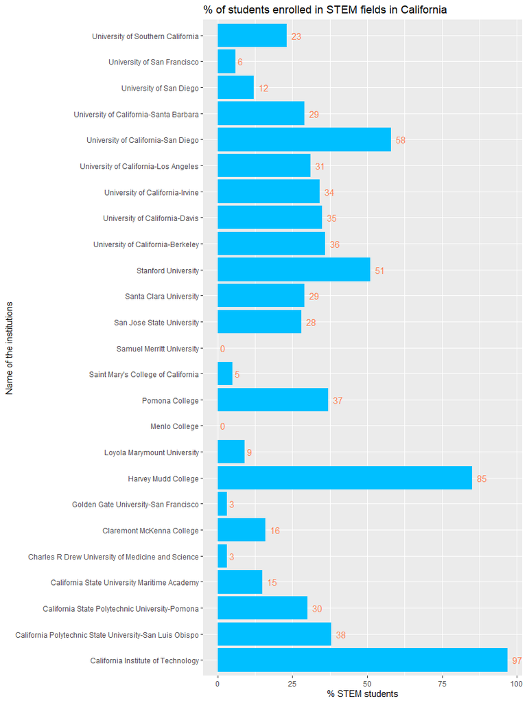

```r
ggplot(stem_data, # uses this df to create ggplot
       aes(x = stem_percent,
           y = name)) + # assigns x and y axes
         geom_col(show.legend = FALSE,
                  position = "dodge",
                  stat = "identity",
                  fill = "deepskyblue1") + # chooses the geom, no legends
       geom_text(aes(label = stem_percent), vjust = 0.5, hjust = -0.5, color = "coral") +
         labs(x = "% STEM students",
              y = "Name of the institutions",
              title = "% of students enrolled in STEM fields in California") + # adds labels to the axes and title
         theme(plot.title = element_text(hjust = 0)) + # aligns plot title
         theme_grey() # chooses this theme
```

#### Save plot #3

```r
ggsave(here("Output","STEM in California.png"),
       width = 10, height = 8) # in inches)
```

Refer to the readme file to know about other categories that can be compared and evaluated to choose the best university to pursue your education. These are some of the data files that were not covered by me:

- *tuition_income* : Contains data for net amount of tuition that is paid after deducting on and off campus scholarships
- *diversity_school* : Contains data on the number of students belonging to different racial communities have been accepted to these institutions

## Start researching ahead of time!